# MPG Analysis - AUTO VS MANUAL

Tommy Brant

February 4, 2019

## EXECUTIVE SUMMARY

The intent of this analysis is to explore and evaluate the relationship between transmission and miles per gallon(MPG) in the mtcars data set. Firstly, we work to identify a good model that includes transmission type, and infer from said model to determine if transmission type is an appropriate variable to predict miles per gallon. This will include different modeling techniques, such as Linear Regression Models and Generalize Linear Regression Models. With these models, we determine that transmission type is not a good variable to determine MPG, nor can the difference in MPG between transmission types be quantified solely based on transmission type.

## LOAD DATA and EXPLORATORY ANALYSIS

Since the mtcars data set is already part of R, loading the data is simple:

```r
library(ggplot2)
library(GGally)
data(mtcars)
```

Exploratory Analysis

1. Look at data frame variables, and linear model factoring in all variables

```
##  [1] "mpg"  "cyl"  "disp" "hp"   "drat" "wt"   "qsec" "vs"   "am"   "gear"
## [11] "carb"
```

```
##
## Call:
## lm(formula = mpg ~ ., data = mtcars)
##
## Residuals:
##     Min      1Q  Median      3Q     Max
## -3.4506 -1.6044 -0.1196  1.2193  4.6271
##
## Coefficients:
##             Estimate Std. Error t value Pr(>|t|)
## (Intercept) 12.30337   18.71788   0.657   0.5181
## cyl         -0.11144    1.04502  -0.107   0.9161
## disp         0.01334    0.01786   0.747   0.4635
## hp          -0.02148    0.02177  -0.987   0.3350
## drat         0.78711    1.63537   0.481   0.6353
## wt          -3.71530    1.89441  -1.961   0.0633 .
## qsec         0.82104    0.73084   1.123   0.2739
## vs           0.31776    2.10451   0.151   0.8814
## am           2.52023    2.05665   1.225   0.2340
## gear         0.65541    1.49326   0.439   0.6652
## carb        -0.19942    0.82875  -0.241   0.8122
## ---
## Signif. codes:  0 '***' 0.001 '**' 0.01 '*' 0.05 '.' 0.1 ' ' 1
##
## Residual standard error: 2.65 on 21 degrees of freedom
## Multiple R-squared:  0.869,  Adjusted R-squared:  0.8066
## F-statistic: 13.93 on 10 and 21 DF,  p-value: 3.793e-07
```

# Model Creation

The following models are used in this analysis

1. Linear Regression Model
2. GLM

## Linear Regression Model

Using the Linear Regressions Models, let us see what kind of relationship am and mpg have.

```r
fit1 <- lm(mpg ~ as.factor(am) ,data=mtcars)
coef(fit1)
```

```
##    (Intercept) as.factor(am)1
##      17.147368       7.244939
```

```r
#P value < 0.05, so am is an appropriate interaction term.
summary(fit1)
```

```
##
## Call:
## lm(formula = mpg ~ as.factor(am), data = mtcars)
##
## Residuals:
##     Min      1Q  Median      3Q     Max
## -9.3923 -3.0923 -0.2974  3.2439  9.5077
##
## Coefficients:
##                Estimate Std. Error t value Pr(>|t|)
## (Intercept)      17.147      1.125  15.247 1.13e-15 ***
## as.factor(am)1    7.245      1.764   4.106 0.000285 ***
## ---
## Signif. codes:  0 '***' 0.001 '**' 0.01 '*' 0.05 '.' 0.1 ' ' 1
##
## Residual standard error: 4.902 on 30 degrees of freedom
## Multiple R-squared:  0.3598, Adjusted R-squared:  0.3385
## F-statistic: 16.86 on 1 and 30 DF,  p-value: 0.000285
```

The intercept is 17.1473684. This is the the baseline mpg. The slope is 7.2449393. This suggests that there is a 7 mpg increase when going from automatic to manual transmission.

The P value for am less than 0.05, which suggests am is a siginificant predictor. However, the low R-squared value, 0.3597989 is a cause for concern. This is an indicator of poor model fit. We will proceed to investigate the residual plot.

See Appendix A, Figure 1 for the residual plot for this model.

Note the gap between the predicted values and the actual results. We will compare this to our next model, as this one is a poor fit.

```r
fit2 <- lm(mpg ~ as.factor(am) + cyl ,data=mtcars)
coef(fit2)
```

```
##    (Intercept) as.factor(am)1            cyl
##      34.522443       2.567035      -2.500958
```

```r
summary(fit2)
```

```
##
## Call:
## lm(formula = mpg ~ as.factor(am) + cyl, data = mtcars)
##
## Residuals:
##     Min      1Q  Median      3Q     Max
## -5.6856 -1.7172 -0.2657  1.8838  6.8144
##
## Coefficients:
##                Estimate Std. Error t value Pr(>|t|)
## (Intercept)     34.5224     2.6032  13.262 7.69e-14 ***
## as.factor(am)1   2.5670     1.2914   1.988   0.0564 .
## cyl             -2.5010     0.3608  -6.931 1.28e-07 ***
## ---
## Signif. codes:  0 '***' 0.001 '**' 0.01 '*' 0.05 '.' 0.1 ' ' 1
##
## Residual standard error: 3.059 on 29 degrees of freedom
## Multiple R-squared:  0.759,  Adjusted R-squared:  0.7424
## F-statistic: 45.67 on 2 and 29 DF,  p-value: 1.094e-09
```

For this model, note the R squared value, 0.7590135 is substantially higher than model fit1. Although we would like R squared to to be higher, we will conclude this model is sufficent for progressing our analysis.

See Appendix A, Figure 2 for the residual plot for this model.

In comparing Figure 1 to Figure 2, we can see that the difference in fitted values to actual values is much less in this model.

Since we’ve found our model of choice, let’s determine if the transmission type is a good predictor for miles per gallon. We can do this by looking at the P value.

If the number of cylinders, cyl, is held constant, P value for am is greater than 0.05, which suggests that am is not a significant interaction term to influence the outcome miles per gallon.

## Generalized Linear Models

Using Generalized Linear Models, let’s see use the same models and predictors as our previous linear regression models.

```r
glm1 <- glm(mpg ~ as.factor(am), family="gaussian", data=mtcars)
summary(glm1)
```

```
##
## Call:
## glm(formula = mpg ~ as.factor(am), family = "gaussian", data = mtcars)
##
## Deviance Residuals:
##     Min       1Q   Median       3Q      Max
## -9.3923  -3.0923  -0.2974   3.2439   9.5077
##
## Coefficients:
##                Estimate Std. Error t value Pr(>|t|)
## (Intercept)      17.147      1.125  15.247 1.13e-15 ***
## as.factor(am)1    7.245      1.764   4.106 0.000285 ***
## ---
## Signif. codes:  0 '***' 0.001 '**' 0.01 '*' 0.05 '.' 0.1 ' ' 1
##
## (Dispersion parameter for gaussian family taken to be 24.02989)
##
##     Null deviance: 1126.0  on 31  degrees of freedom
## Residual deviance:  720.9  on 30  degrees of freedom
## AIC: 196.48
##
## Number of Fisher Scoring iterations: 2
```

```r
glm2 <- glm(mpg ~ as.factor(am) + cyl, family="gaussian", data=mtcars)
summary(glm2)
```

```
##
## Call:
## glm(formula = mpg ~ as.factor(am) + cyl, family = "gaussian",
##     data = mtcars)
##
## Deviance Residuals:
##     Min       1Q   Median       3Q      Max
## -5.6856  -1.7172  -0.2657   1.8838   6.8144
##
## Coefficients:
##                Estimate Std. Error t value Pr(>|t|)
## (Intercept)     34.5224     2.6032  13.262 7.69e-14 ***
## as.factor(am)1   2.5670     1.2914   1.988   0.0564 .
## cyl             -2.5010     0.3608  -6.931 1.28e-07 ***
## ---
## Signif. codes:  0 '***' 0.001 '**' 0.01 '*' 0.05 '.' 0.1 ' ' 1
##
## (Dispersion parameter for gaussian family taken to be 9.357314)
##
##     Null deviance: 1126.05  on 31  degrees of freedom
## Residual deviance:  271.36  on 29  degrees of freedom
## AIC: 167.22
##
## Number of Fisher Scoring iterations: 2
```

Although with GLM we don’t have an absolute model indicator like R squared to help determine if this is good or bad model fit, we can look at the AIC rating between the two models. AIC for glm1 is 196.4843801. AIC for glm2 is 167.2190506. AIC rating of the first model, glm1, is higher than the AIC rating of the second model, glm2. This indicates that glm2 has better model fit. To confirm this, let’s look at the residual plots of glm1 and glm2, and see which one has the lowest differences in actual and fitted values.

See Appendix A, Figure 3 and Figure 4, respectively, for the residual plot for this model.

In comparing Figure 3 to Figure 4, we can see that the difference in fitted values to actual values is much less in glm2. This is also an indicator that glm2 is a better model than glm1.

Since we’ve found our model of choice, let’s determine if the transmission type is a good predictor for miles per gallon. We can do this by looking at the P value.

If the number of cylinders, cyl, is held constant, P value for am is greater than 0.05, which suggests that am is not a significant interaction term to influence the outcome mpg. this is consistent with our findings from linear regression modeling that am is not a significant variable to predict miles per gallon.

## CONCLUSION

When we tried using a Linear Regression model using transmission type, am, solely as a predictor, there were multiple indications it was a poor model. When we did identify a good model that included am, we find that it wasn’t a significant variable to be used as a predictor. In generalized linear modeling, we identified a good model that included am, we find again that it wasn’t a significant varaible to be used as a predictor. In conclusion, transmission type is not a good variable to determine MPG, nor can the difference in MPG between transmission types be quantified solely based on transmission type.

## ASSUMPTIONS USED

Assumptions and uncertainties are list below:Assumptions

1. For a normal distribution, assume that all data is independent and identically distributed random variables.
2. For T confidence intervals, assume the subjects are relevant samples from a population of subjects

## APPENDIX A

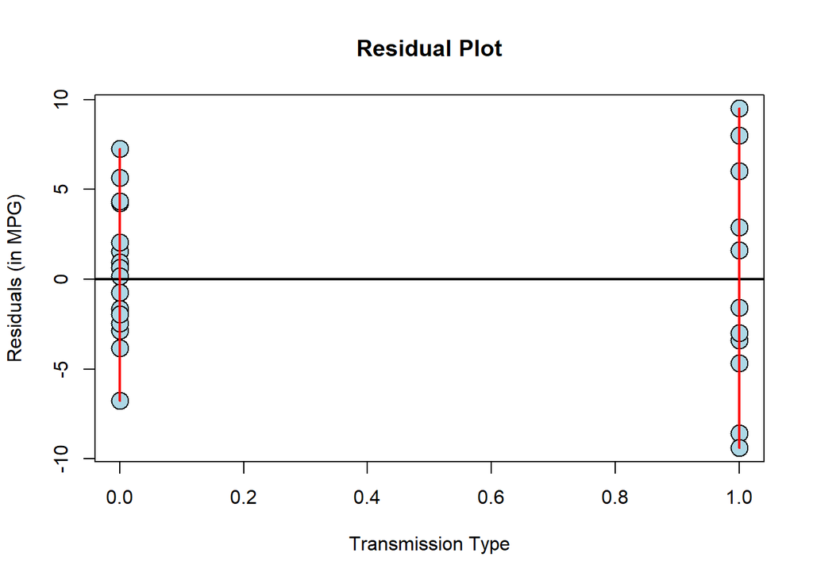

```r
#FIGURE 1 - RESIDUAL PLOT AM VS MPG
x1<-mtcars$am
y1<-mtcars$mpg
n1<-length(mtcars$mpg)
e1<-resid(fit1)
plot(x1, e1, xlab="Transmission Type", ylab="Residuals (in MPG)", bg="lightblue", col="black", cex=2, pch=21, main="Residual Plot")
abline(h=0,lwd=2)
for (i in 1:n1)
 lines(c(x1[i], x1[i]), c(e1[i],0), col="red", lwd=2)
```

Figure 1: Residual Plot for fit1

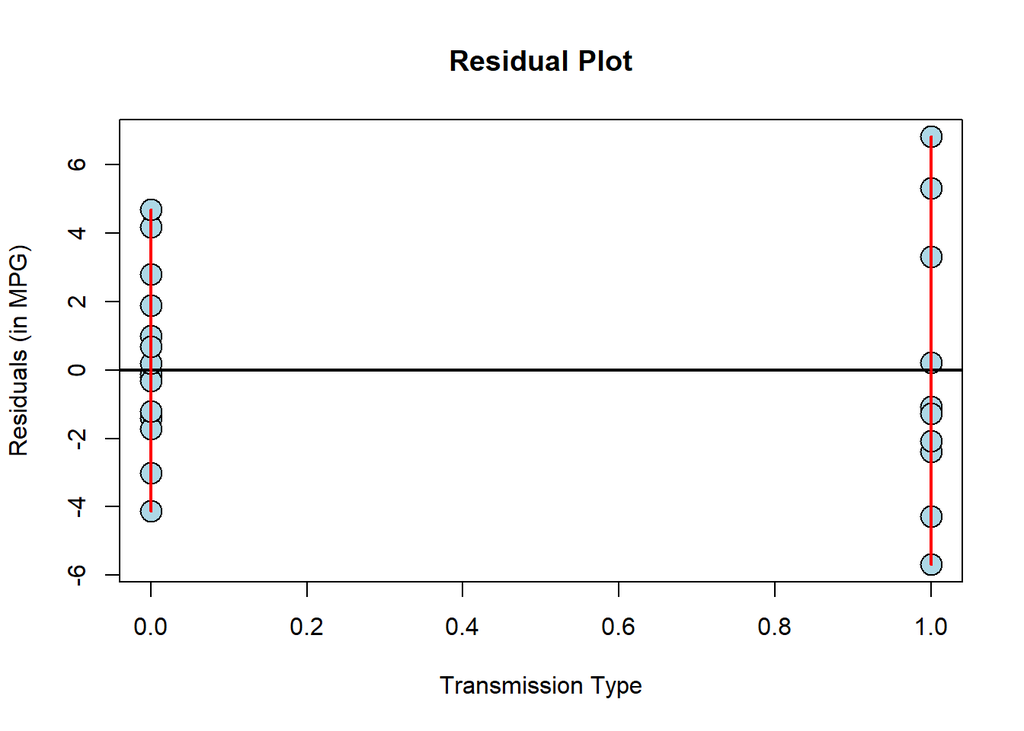

```r
##FIGURE 2 - RESIDUAL PLOT FOR AM + CYL VS MPG
x2<-mtcars$am
y2<-mtcars$mpg
n2<-length(mtcars$mpg)
e2<-resid(fit2)
plot(x2, e2, xlab="Transmission Type", ylab="Residuals (in MPG)", bg="lightblue", col="black", cex=2, pch=21, main="Residual Plot")
abline(h=0,lwd=2)
for (i in 1:n2)
 lines(c(x2[i], x2[i]), c(e2[i],0), col="red", lwd=2)
```

Figure 2: Residual Plot for fit2

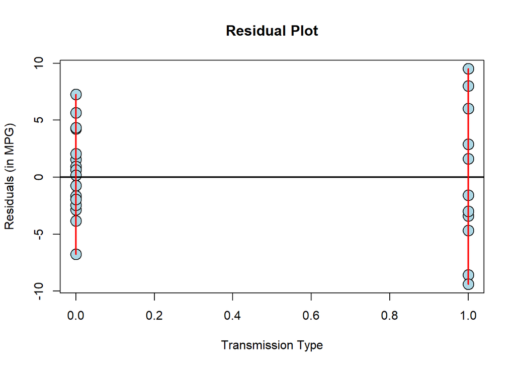

```r
##FIGURE 3 - RESIDUAL PLOT FOR AM VS MPG
x3<-mtcars$am
y3<-mtcars$mpg
n3<-length(mtcars$mpg)
e3<-resid(glm1)
plot(x3, e3, xlab="Transmission Type", ylab="Residuals (in MPG)", bg="lightblue", col="black", cex=2, pch=21, main="Residual Plot")
abline(h=0,lwd=2)
for (i in 1:n1)
 lines(c(x3[i], x3[i]), c(e3[i],0), col="red", lwd=2)
```

Figure 3: Residual Plot for glm1

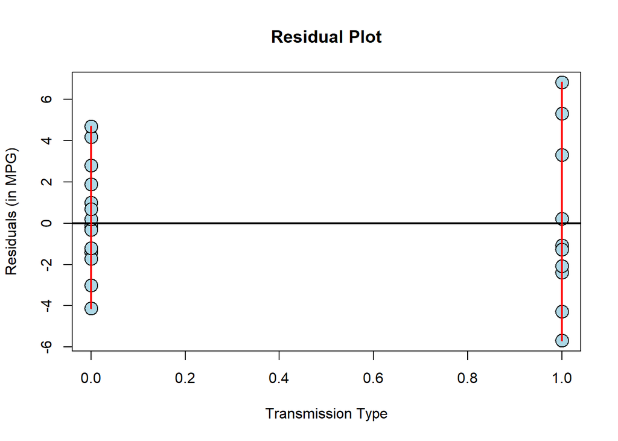

```r
##FIGURE 4 - RESIDUAL PLOT FOR AM + CYL VS MPG
x4<-mtcars$am
y4<-mtcars$mpg
n4<-length(mtcars$mpg)
e4<-resid(glm2)
plot(x4, e4, xlab="Transmission Type", ylab="Residuals (in MPG)", bg="lightblue", col="black", cex=2, pch=21, main="Residual Plot")
abline(h=0,lwd=2)
for (i in 1:n1)
 lines(c(x4[i], x4[i]), c(e4[i],0), col="red", lwd=2)
```

Figure 4: Residual Plot for glm2